# Bank Telemarketing Analysis

#### Modeling process

```r
bankTrain <- bankTrain %>%
  filter(logDuration != -Inf)

reg <- glm(deposit ~ ., bankTrain, family = binomial)
summary(reg)
```

```
##
## Call:
## glm(formula = deposit ~ ., family = binomial, data = bankTrain)
##
## Deviance Residuals:
##     Min       1Q   Median       3Q      Max
## -3.5561  -0.3189  -0.1485  -0.0632   3.7500
##
## Coefficients:
##                                Estimate Std. Error z value Pr(>|z|)
## (Intercept)                  -2.530e+02  4.478e+01  -5.651 1.59e-08 ***
## age                          -2.421e-03  2.850e-03  -0.850 0.395576
## jobblue-collar               -2.300e-01  9.211e-02  -2.497 0.012529 *
## jobentrepreneur              -1.958e-01  1.453e-01  -1.348 0.177596
## jobhousemaid                 -1.132e-01  1.708e-01  -0.663 0.507475
## jobmanagement                -8.614e-03  9.853e-02  -0.087 0.930332
## jobretired                    4.055e-01  1.268e-01   3.198 0.001383 **
## jobself-employed             -1.192e-01  1.356e-01  -0.879 0.379300
## jobservices                  -2.502e-01  1.006e-01  -2.486 0.012911 *
## jobstudent                    2.193e-01  1.428e-01   1.536 0.124587
## jobtechnician                 2.858e-02  8.226e-02   0.347 0.728259
## jobunemployed                 1.060e-01  1.473e-01   0.719 0.471833
## maritalmarried               -8.433e-04  7.851e-02  -0.011 0.991430
## maritalsingle                 4.821e-03  9.012e-02   0.053 0.957341
## educationbasic.6y             1.770e-01  1.346e-01   1.315 0.188473
## educationbasic.9y             8.958e-02  1.067e-01   0.840 0.400958
## educationhigh.school          1.414e-01  1.051e-01   1.345 0.178665
## educationilliterate           1.181e+00  8.270e-01   1.428 0.153161
## educationprofessional.course  2.212e-01  1.150e-01   1.923 0.054458 .
## educationuniversity.degree    2.847e-01  1.060e-01   2.686 0.007236 **
## housing1                      1.754e-04  4.763e-02   0.004 0.997062
## loan1                        -5.632e-02  6.627e-02  -0.850 0.395396
## telephone1                   -6.686e-01  9.534e-02  -7.012 2.35e-12 ***
## monthaug                      1.193e+00  1.482e-01   8.045 8.60e-16 ***
## monthdec                      4.219e-01  2.532e-01   1.666 0.095679 .
## monthjul                      3.602e-01  1.144e-01   3.148 0.001643 **
## monthjun                     -3.054e-01  1.510e-01  -2.022 0.043135 *
## monthmar                      2.478e+00  1.800e-01  13.765  < 2e-16 ***
## monthmay                     -3.496e-01  9.853e-02  -3.548 0.000388 ***
## monthnov                     -3.442e-01  1.403e-01  -2.454 0.014145 *
```

[output cut: 9 more lines]

```
## cons.price.idx                2.342e+00  2.974e-01   7.878 3.34e-15 ***
## cons.conf.idx                 2.603e-02  9.512e-03   2.737 0.006208 **
## euribor3m                     5.835e-01  1.523e-01   3.830 0.000128 ***
## nr.employed                   3.442e-03  3.605e-03   0.955 0.339654
## logDuration                   2.235e+00  4.037e-02  55.354  < 2e-16 ***
## ---
## Signif. codes:  0 '***' 0.001 '**' 0.01 '*' 0.05 '.' 0.1 ' ' 1
##
## (Dispersion parameter for binomial family taken to be 1)
##
##     Null deviance: 21272  on 30593  degrees of freedom
## Residual deviance: 12182  on 30550  degrees of freedom
## AIC: 12270
##
## Number of Fisher Scoring iterations: 7
```

We would remove `age`, `job`, `marital`, `education`, `housing`, `loan`, `day_of_week`, `campaign`, `nr.employed`

```r
reg2 <- glm(deposit ~ telephone + month + previous + emp.var.rate + cons.price.idx + cons.conf.idx + euribor3m + logDuration, bankTrain, family = binomial)
summary(reg2)
```

```
##
## Call:
## glm(formula = deposit ~ telephone + month + previous + emp.var.rate +
##     cons.price.idx + cons.conf.idx + euribor3m + logDuration,
##     family = binomial, data = bankTrain)
##
## Deviance Residuals:
##     Min       1Q   Median       3Q      Max
## -3.5786  -0.3211  -0.1504  -0.0651   3.5965
##
## Coefficients:
##                  Estimate Std. Error z value Pr(>|z|)
## (Intercept)    -2.180e+02  1.247e+01 -17.482  < 2e-16 ***
## telephone1     -6.623e-01  9.034e-02  -7.332 2.27e-13 ***
## monthaug        1.248e+00  1.325e-01   9.419  < 2e-16 ***
## monthdec        3.976e-01  2.377e-01   1.673 0.094366 .
## monthjul        3.916e-01  1.125e-01   3.482 0.000498 ***
## monthjun       -2.219e-01  1.222e-01  -1.816 0.069418 .
## monthmar        2.465e+00  1.514e-01  16.282  < 2e-16 ***
## monthmay       -4.003e-01  8.953e-02  -4.471 7.77e-06 ***
## monthnov       -3.411e-01  1.252e-01  -2.724 0.006446 **
## monthoct        3.845e-01  1.492e-01   2.577 0.009969 **
## monthsep        8.062e-01  1.612e-01   5.002 5.68e-07 ***
## previous        1.597e-01  3.938e-02   4.055 5.02e-05 ***
## emp.var.rate   -1.957e+00  1.369e-01 -14.303  < 2e-16 ***
## cons.price.idx  2.153e+00  1.291e-01  16.676  < 2e-16 ***
## cons.conf.idx   2.292e-02  6.733e-03   3.405 0.000662 ***
## euribor3m       7.030e-01  1.035e-01   6.794 1.09e-11 ***
## logDuration     2.223e+00  4.009e-02  55.456  < 2e-16 ***
## ---
## Signif. codes:  0 '***' 0.001 '**' 0.01 '*' 0.05 '.' 0.1 ' ' 1
##
## (Dispersion parameter for binomial family taken to be 1)
##
##     Null deviance: 21272  on 30593  degrees of freedom
## Residual deviance: 12267  on 30577  degrees of freedom
## AIC: 12301
##
## Number of Fisher Scoring iterations: 7
```

```r
lrm(deposit ~ telephone + month + previous + emp.var.rate + cons.price.idx + cons.conf.idx + euribor3m + logDuration, bankTrain)
```

```
## Logistic Regression Model
##
##  lrm(formula = deposit ~ telephone + month + previous + emp.var.rate +
##      cons.price.idx + cons.conf.idx + euribor3m + logDuration,
##      data = bankTrain)
##
##                         Model Likelihood    Discrimination    Rank Discrim.
##                               Ratio Test           Indexes          Indexes
##  Obs         30594    LR chi2    9005.42    R2       0.509    C       0.933
##   0          27212    d.f.            16    g        2.764    Dxy     0.866
##   1           3382    Pr(> chi2) <0.0001    gr      15.870    gamma   0.866
##  max |deriv| 1e-09                          gp       0.165    tau-a   0.170
##                                             Brier    0.063
##
##                 Coef      S.E.    Wald Z Pr(>|Z|)
##  Intercept      -218.0026 12.4701 -17.48 <0.0001
##  telephone=1      -0.6623  0.0903  -7.33 <0.0001
##  month=aug         1.2484  0.1325   9.42 <0.0001
##  month=dec         0.3976  0.2377   1.67 0.0944
##  month=jul         0.3916  0.1125   3.48 0.0005
##  month=jun        -0.2219  0.1222  -1.82 0.0694
##  month=mar         2.4646  0.1514  16.28 <0.0001
##  month=may        -0.4003  0.0895  -4.47 <0.0001
##  month=nov        -0.3411  0.1252  -2.72 0.0064
##  month=oct         0.3845  0.1492   2.58 0.0100
##  month=sep         0.8062  0.1612   5.00 <0.0001
##  previous          0.1597  0.0394   4.05 <0.0001
##  emp.var.rate     -1.9575  0.1369 -14.30 <0.0001
##  cons.price.idx    2.1529  0.1291  16.68 <0.0001
##  cons.conf.idx     0.0229  0.0067   3.40 0.0007
##  euribor3m         0.7030  0.1035   6.79 <0.0001
##  logDuration       2.2232  0.0401  55.46 <0.0001
##
```

We may consider remove `month`

```r
reg3 <- glm(deposit ~ telephone + previous + emp.var.rate + cons.price.idx + euribor3m + cons.conf.idx + logDuration, bankTrain, family = binomial)
summary(reg3)
```

```
##
## Call:
## glm(formula = deposit ~ telephone + previous + emp.var.rate +
##     cons.price.idx + euribor3m + cons.conf.idx + logDuration,
##     family = binomial, data = bankTrain)
##
## Deviance Residuals:
##     Min       1Q   Median       3Q      Max
## -3.1289  -0.3441  -0.1633  -0.0712   3.7512
##
## Coefficients:
##                  Estimate Std. Error z value Pr(>|z|)
## (Intercept)    -1.646e+02  7.453e+00 -22.080  < 2e-16 ***
## telephone1     -1.146e+00  7.148e-02 -16.026  < 2e-16 ***
## previous        1.411e-01  3.773e-02   3.739 0.000185 ***
## emp.var.rate   -1.045e+00  7.954e-02 -13.133  < 2e-16 ***
## cons.price.idx  1.647e+00  7.786e-02  21.149  < 2e-16 ***
## euribor3m       3.723e-02  6.222e-02   0.598 0.549589
## cons.conf.idx   9.261e-02  4.803e-03  19.284  < 2e-16 ***
## logDuration     2.124e+00  3.839e-02  55.336  < 2e-16 ***
## ---
## Signif. codes:  0 '***' 0.001 '**' 0.01 '*' 0.05 '.' 0.1 ' ' 1
##
## (Dispersion parameter for binomial family taken to be 1)
##
##     Null deviance: 21272  on 30593  degrees of freedom
## Residual deviance: 12803  on 30586  degrees of freedom
## AIC: 12819
##
## Number of Fisher Scoring iterations: 7
```

```r
lrm(deposit ~ telephone + previous + emp.var.rate + cons.price.idx + euribor3m + cons.conf.idx + logDuration, bankTrain)
```

```
## Logistic Regression Model
##
##  lrm(formula = deposit ~ telephone + previous + emp.var.rate +
##      cons.price.idx + euribor3m + cons.conf.idx + logDuration,
##      data = bankTrain)
##
##                         Model Likelihood    Discrimination    Rank Discrim.
##                               Ratio Test           Indexes          Indexes
##  Obs         30594    LR chi2    8469.29    R2       0.483    C       0.922
##   0          27212    d.f.             7    g        2.655    Dxy     0.843
##   1           3382    Pr(> chi2) <0.0001    gr      14.231    gamma   0.843
##  max |deriv| 1e-09                          gp       0.161    tau-a   0.166
##                                             Brier    0.064
##
##                 Coef      S.E.   Wald Z Pr(>|Z|)
##  Intercept      -164.5669 7.4532 -22.08 <0.0001
##  telephone=1      -1.1456 0.0715 -16.03 <0.0001
##  previous          0.1411 0.0377   3.74 0.0002
##  emp.var.rate     -1.0447 0.0795 -13.13 <0.0001
##  cons.price.idx    1.6467 0.0779  21.15 <0.0001
##  euribor3m         0.0372 0.0622   0.60 0.5496
##  cons.conf.idx     0.0926 0.0048  19.28 <0.0001
##  logDuration       2.1243 0.0384  55.34 <0.0001
##
```

Also, remove `euribor3m`.

```r
reg4 <- glm(deposit ~ telephone + previous + emp.var.rate + cons.price.idx + cons.conf.idx + logDuration, bankTrain, family = binomial)
summary(reg4)
```

```
##
## Call:
## glm(formula = deposit ~ telephone + previous + emp.var.rate +
##     cons.price.idx + cons.conf.idx + logDuration, family = binomial,
##     data = bankTrain)
##
## Deviance Residuals:
##     Min       1Q   Median       3Q      Max
## -3.1344  -0.3443  -0.1632  -0.0712   3.7661
##
## Coefficients:
##                  Estimate Std. Error z value Pr(>|z|)
## (Intercept)    -1.618e+02  5.781e+00 -27.982  < 2e-16 ***
## telephone1     -1.134e+00  6.899e-02 -16.444  < 2e-16 ***
## previous        1.376e-01  3.729e-02   3.691 0.000223 ***
## emp.var.rate   -9.994e-01  2.418e-02 -41.330  < 2e-16 ***
## cons.price.idx  1.619e+00  6.193e-02  26.134  < 2e-16 ***
## cons.conf.idx   9.366e-02  4.468e-03  20.963  < 2e-16 ***
## logDuration     2.124e+00  3.838e-02  55.336  < 2e-16 ***
## ---
## Signif. codes:  0 '***' 0.001 '**' 0.01 '*' 0.05 '.' 0.1 ' ' 1
##
## (Dispersion parameter for binomial family taken to be 1)
##
##     Null deviance: 21272  on 30593  degrees of freedom
## Residual deviance: 12803  on 30587  degrees of freedom
## AIC: 12817
##
## Number of Fisher Scoring iterations: 7
```

```r
lrm(deposit ~ telephone + previous + emp.var.rate + cons.price.idx + cons.conf.idx + logDuration, bankTrain)
```

```
## Logistic Regression Model
##
##  lrm(formula = deposit ~ telephone + previous + emp.var.rate +
##      cons.price.idx + cons.conf.idx + logDuration, data = bankTrain)
##
##                         Model Likelihood    Discrimination    Rank Discrim.
##                               Ratio Test           Indexes          Indexes
##  Obs         30594    LR chi2    8468.93    R2       0.483    C       0.922
##   0          27212    d.f.             6    g        2.655    Dxy     0.843
##   1           3382    Pr(> chi2) <0.0001    gr      14.221    gamma   0.843
##  max |deriv| 2e-09                          gp       0.161    tau-a   0.166
##                                             Brier    0.064
##
##                 Coef      S.E.   Wald Z Pr(>|Z|)
##  Intercept      -161.7572 5.7807 -27.98 <0.0001
##  telephone=1      -1.1345 0.0690 -16.44 <0.0001
##  previous          0.1376 0.0373   3.69 0.0002
##  emp.var.rate     -0.9994 0.0242 -41.33 <0.0001
##  cons.price.idx    1.6185 0.0619  26.13 <0.0001
##  cons.conf.idx     0.0937 0.0045  20.96 <0.0001
##  logDuration       2.1239 0.0384  55.34 <0.0001
##
```

```r
# Drop-in deviance tests

pchisq(21272-12182,43,lower.tail = FALSE)
```

```
## [1] 0
```

```r
pchisq(21272-12267,16,lower.tail = FALSE)
```

```
## [1] 0
```

```r
pchisq(21272-12803,7,lower.tail = FALSE)
```

```
## [1] 0
```

```r
pchisq(21272-12803,6,lower.tail = FALSE)
```

```
## [1] 0
```

We will have to now consider moving forward with one of the models. We should definitely eliminate model 1 as it has too many varriables with statistically insignificant p-values. We should also eliminate model 3 because `euribor3m` has a statistically insignificant p-values. We are left with model 2 and 4. The drop-in deviance tests yield 0 for all models, indicating that the probability of getting a larger or equal drop-in deviance is also statistically significant (lower than 0.05). This indicates that it’s hard to have a larger or equal drop-in deviance. Thus, our models are adequate. They are significantly better than the null model, explaining a larger amount of variation of `deposit`.

Since the drop-in deviance test doesn’t point out which model is better, we will take a look at the residual deviance and Dxy.

```r
lrm(deposit ~ telephone + month + previous + emp.var.rate + cons.price.idx + cons.conf.idx + euribor3m + logDuration, bankTrain)
```

```
## Logistic Regression Model
##
##  lrm(formula = deposit ~ telephone + month + previous + emp.var.rate +
##      cons.price.idx + cons.conf.idx + euribor3m + logDuration,
##      data = bankTrain)
##
##                         Model Likelihood    Discrimination    Rank Discrim.
##                               Ratio Test           Indexes          Indexes
##  Obs         30594    LR chi2    9005.42    R2       0.509    C       0.933
##   0          27212    d.f.            16    g        2.764    Dxy     0.866
##   1           3382    Pr(> chi2) <0.0001    gr      15.870    gamma   0.866
##  max |deriv| 1e-09                          gp       0.165    tau-a   0.170
##                                             Brier    0.063
##
##                 Coef      S.E.    Wald Z Pr(>|Z|)
##  Intercept      -218.0026 12.4701 -17.48 <0.0001
##  telephone=1      -0.6623  0.0903  -7.33 <0.0001
##  month=aug         1.2484  0.1325   9.42 <0.0001
##  month=dec         0.3976  0.2377   1.67 0.0944
##  month=jul         0.3916  0.1125   3.48 0.0005
##  month=jun        -0.2219  0.1222  -1.82 0.0694
##  month=mar         2.4646  0.1514  16.28 <0.0001
##  month=may        -0.4003  0.0895  -4.47 <0.0001
##  month=nov        -0.3411  0.1252  -2.72 0.0064
##  month=oct         0.3845  0.1492   2.58 0.0100
##  month=sep         0.8062  0.1612   5.00 <0.0001
##  previous          0.1597  0.0394   4.05 <0.0001
##  emp.var.rate     -1.9575  0.1369 -14.30 <0.0001
##  cons.price.idx    2.1529  0.1291  16.68 <0.0001
##  cons.conf.idx     0.0229  0.0067   3.40 0.0007
##  euribor3m         0.7030  0.1035   6.79 <0.0001
##  logDuration       2.2232  0.0401  55.46 <0.0001
##
```

```r
lrm(deposit ~ telephone + previous + emp.var.rate + cons.price.idx + cons.conf.idx + logDuration, bankTrain)
```

```
## Logistic Regression Model
##
##  lrm(formula = deposit ~ telephone + previous + emp.var.rate +
##      cons.price.idx + cons.conf.idx + logDuration, data = bankTrain)
##
##                         Model Likelihood    Discrimination    Rank Discrim.
##                               Ratio Test           Indexes          Indexes
##  Obs         30594    LR chi2    8468.93    R2       0.483    C       0.922
##   0          27212    d.f.             6    g        2.655    Dxy     0.843
##   1           3382    Pr(> chi2) <0.0001    gr      14.221    gamma   0.843
##  max |deriv| 2e-09                          gp       0.161    tau-a   0.166
##                                             Brier    0.064
##
##                 Coef      S.E.   Wald Z Pr(>|Z|)
##  Intercept      -161.7572 5.7807 -27.98 <0.0001
##  telephone=1      -1.1345 0.0690 -16.44 <0.0001
##  previous          0.1376 0.0373   3.69 0.0002
##  emp.var.rate     -0.9994 0.0242 -41.33 <0.0001
##  cons.price.idx    1.6185 0.0619  26.13 <0.0001
##  cons.conf.idx     0.0937 0.0045  20.96 <0.0001
##  logDuration       2.1239 0.0384  55.34 <0.0001
##
```

Clearly, model 2 has a smaller residual deviance (12267) compared to model 4 (12803). Model 2 also has a larger Dxy than model 4, 0.866 compared to 0.843. This means that model 2 fits the data more than model 4, and the variables in model 2 are more significant.  
The only concern we have is that some of the month is not significant. We may convert month into different Bernoulli variables and eliminate those that are not significant or we may run a drop-in deviance test for month to see if it offers a greater model than the null model.

```r
# Drop-in deviance test for month
pchisq(12803-12267,16-7,lower.tail = FALSE)
```

```
## [1] 1.115819e-109
```

It appears that month is quite significant since the drop-in test yields 1.11*10^{-109} as the p-value. After some experiment, we realize that using august as the baseline would make all the p-values significant. This can happen due to the fact that the `monthaug` may affect `deposit` different from other months a lot.

```r
bankTrain$month <- relevel(bankTrain$month, ref = "aug")
reg5 <- glm(deposit ~ telephone + month + previous + emp.var.rate + cons.price.idx + cons.conf.idx + euribor3m + logDuration, bankTrain, family = binomial)
summary(reg5)
```

```
##
## Call:
## glm(formula = deposit ~ telephone + month + previous + emp.var.rate +
##     cons.price.idx + cons.conf.idx + euribor3m + logDuration,
##     family = binomial, data = bankTrain)
##
## Deviance Residuals:
##     Min       1Q   Median       3Q      Max
## -3.5786  -0.3211  -0.1504  -0.0651   3.5965
##
## Coefficients:
##                  Estimate Std. Error z value Pr(>|z|)
## (Intercept)    -2.168e+02  1.242e+01 -17.447  < 2e-16 ***
## telephone1     -6.623e-01  9.034e-02  -7.332 2.27e-13 ***
## monthapr       -1.248e+00  1.325e-01  -9.419  < 2e-16 ***
## monthdec       -8.508e-01  2.381e-01  -3.574 0.000352 ***
## monthjul       -8.568e-01  1.180e-01  -7.258 3.92e-13 ***
## monthjun       -1.470e+00  1.599e-01  -9.196  < 2e-16 ***
## monthmar        1.216e+00  1.551e-01   7.841 4.48e-15 ***
## monthmay       -1.649e+00  1.089e-01 -15.145  < 2e-16 ***
## monthnov       -1.590e+00  1.446e-01 -10.996  < 2e-16 ***
## monthoct       -8.639e-01  1.584e-01  -5.453 4.96e-08 ***
## monthsep       -4.422e-01  1.532e-01  -2.886 0.003900 **
## previous        1.597e-01  3.938e-02   4.055 5.02e-05 ***
## emp.var.rate   -1.957e+00  1.369e-01 -14.303  < 2e-16 ***
## cons.price.idx  2.153e+00  1.291e-01  16.676  < 2e-16 ***
## cons.conf.idx   2.292e-02  6.733e-03   3.405 0.000662 ***
## euribor3m       7.030e-01  1.035e-01   6.794 1.09e-11 ***
## logDuration     2.223e+00  4.009e-02  55.456  < 2e-16 ***
## ---
## Signif. codes:  0 '***' 0.001 '**' 0.01 '*' 0.05 '.' 0.1 ' ' 1
##
## (Dispersion parameter for binomial family taken to be 1)
##
##     Null deviance: 21272  on 30593  degrees of freedom
## Residual deviance: 12267  on 30577  degrees of freedom
## AIC: 12301
##
## Number of Fisher Scoring iterations: 7
```

```r
lrm(deposit ~ telephone + month + previous + emp.var.rate + cons.price.idx + cons.conf.idx + euribor3m + logDuration, bankTrain)
```

```
## Logistic Regression Model
##
##  lrm(formula = deposit ~ telephone + month + previous + emp.var.rate +
##      cons.price.idx + cons.conf.idx + euribor3m + logDuration,
##      data = bankTrain)
##
##                         Model Likelihood    Discrimination    Rank Discrim.
##                               Ratio Test           Indexes          Indexes
##  Obs         30594    LR chi2    9005.42    R2       0.509    C       0.933
##   0          27212    d.f.            16    g        2.764    Dxy     0.866
##   1           3382    Pr(> chi2) <0.0001    gr      15.870    gamma   0.866
##  max |deriv| 1e-09                          gp       0.165    tau-a   0.170
##                                             Brier    0.063
##
##                 Coef      S.E.    Wald Z Pr(>|Z|)
##  Intercept      -216.7542 12.4238 -17.45 <0.0001
##  telephone=1      -0.6623  0.0903  -7.33 <0.0001
##  month=apr        -1.2484  0.1325  -9.42 <0.0001
##  month=dec        -0.8508  0.2381  -3.57 0.0004
##  month=jul        -0.8568  0.1180  -7.26 <0.0001
##  month=jun        -1.4703  0.1599  -9.20 <0.0001
##  month=mar         1.2161  0.1551   7.84 <0.0001
##  month=may        -1.6488  0.1089 -15.15 <0.0001
##  month=nov        -1.5895  0.1445 -11.00 <0.0001
##  month=oct        -0.8639  0.1584  -5.45 <0.0001
##  month=sep        -0.4422  0.1532  -2.89 0.0039
##  previous          0.1597  0.0394   4.05 <0.0001
##  emp.var.rate     -1.9575  0.1369 -14.30 <0.0001
##  cons.price.idx    2.1529  0.1291  16.68 <0.0001
##  cons.conf.idx     0.0229  0.0067   3.40 0.0007
##  euribor3m         0.7030  0.1035   6.79 <0.0001
##  logDuration       2.2232  0.0401  55.46 <0.0001
##
```

We will move forward with model 2 and try to improve the model by adding interaction terms.

#### Interaction Terms

Since when we remove month, euribor3m is also affected a lot, we will try an interaction term between month and euribor3m.

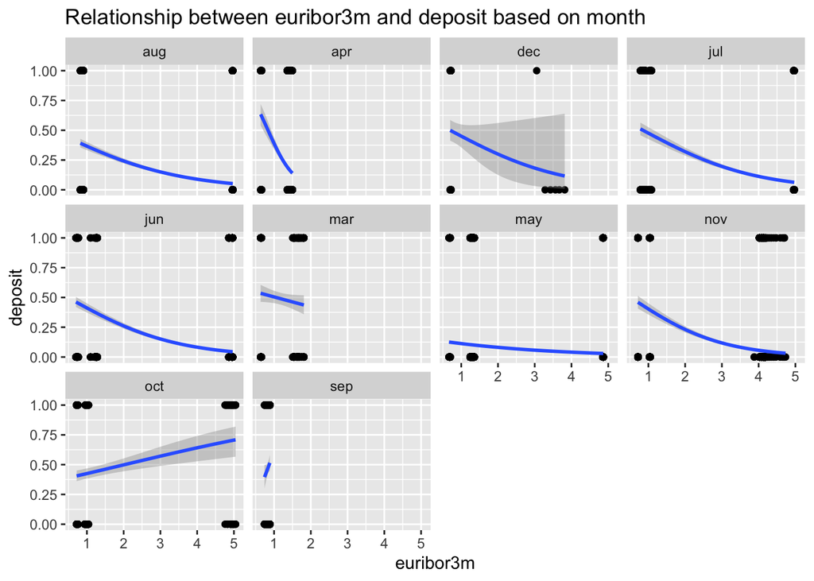

```r
bankTrain %>%
  ggplot(aes(euribor3m, deposit)) + geom_point() +
  stat_smooth(method = "glm",method.args = list(family= "binomial")) +
  facet_wrap(~month) +
  labs(title = "Relationship between euribor3m and deposit based on month")
```

```r
reg6 <- glm(deposit ~ telephone + month + previous + emp.var.rate + cons.price.idx + cons.conf.idx + euribor3m + logDuration + month*euribor3m, bankTrain, family = binomial)
summary(reg6)
```

```
##
## Call:
## glm(formula = deposit ~ telephone + month + previous + emp.var.rate +
##     cons.price.idx + cons.conf.idx + euribor3m + logDuration +
##     month * euribor3m, family = binomial, data = bankTrain)
##
## Deviance Residuals:
##     Min       1Q   Median       3Q      Max
## -4.0986  -0.3117  -0.1434  -0.0614   3.5207
##
## Coefficients:
##                      Estimate Std. Error z value Pr(>|z|)
## (Intercept)        -194.43155   19.41146 -10.016  < 2e-16 ***
## telephone1           -0.49594    0.10055  -4.932 8.12e-07 ***
## monthapr              0.96046    0.49553   1.938 0.052594 .
## monthdec             -1.93622    0.47475  -4.078 4.53e-05 ***
## monthjul             -0.46212    0.23329  -1.981 0.047611 *
## monthjun             -0.27596    0.25487  -1.083 0.278927
## monthmar             -0.71979    0.40586  -1.774 0.076145 .
## monthmay             -0.53290    0.22848  -2.332 0.019684 *
## monthnov             -0.86790    0.24884  -3.488 0.000487 ***
## monthoct             -1.71380    0.20999  -8.161 3.31e-16 ***
## monthsep             -5.56421    2.51206  -2.215 0.026760 *
## previous              0.16019    0.03967   4.038 5.39e-05 ***
## emp.var.rate         -1.52489    0.23337  -6.534 6.39e-11 ***
## cons.price.idx        1.94062    0.20144   9.634  < 2e-16 ***
## cons.conf.idx         0.07708    0.01183   6.515 7.28e-11 ***
## euribor3m             0.43797    0.19249   2.275 0.022885 *
## logDuration           2.27451    0.04097  55.511  < 2e-16 ***
## monthapr:euribor3m   -1.08968    0.40155  -2.714 0.006654 **
## monthdec:euribor3m    1.91503    0.50571   3.787 0.000153 ***
## monthjul:euribor3m   -0.01630    0.05112  -0.319 0.749770
## monthjun:euribor3m   -0.22983    0.05471  -4.201 2.66e-05 ***
## monthmar:euribor3m    2.17512    0.35015   6.212 5.23e-10 ***
## monthmay:euribor3m   -0.28014    0.07477  -3.747 0.000179 ***
## monthnov:euribor3m   -0.06484    0.06480  -1.001 0.317035
## monthoct:euribor3m    1.10094    0.14615   7.533 4.96e-14 ***
## monthsep:euribor3m    6.33062    2.99808   2.112 0.034724 *
## ---
## Signif. codes:  0 '***' 0.001 '**' 0.01 '*' 0.05 '.' 0.1 ' ' 1
##
## (Dispersion parameter for binomial family taken to be 1)
##
##     Null deviance: 21272  on 30593  degrees of freedom
## Residual deviance: 12031  on 30568  degrees of freedom
## AIC: 12083
##
## Number of Fisher Scoring iterations: 7
```

```r
lrm(deposit ~ telephone + month + previous + emp.var.rate + cons.price.idx + cons.conf.idx + euribor3m + logDuration + month*euribor3m + campaign, bankTrain, maxit=1000)
```

```
## Logistic Regression Model
##
##  lrm(formula = deposit ~ telephone + month + previous + emp.var.rate +
##      cons.price.idx + cons.conf.idx + euribor3m + logDuration +
##      month * euribor3m + campaign, data = bankTrain, maxit = 1000)
##
##                         Model Likelihood    Discrimination    Rank Discrim.
##                               Ratio Test           Indexes          Indexes
##  Obs         30594    LR chi2    9244.03    R2       0.520    C       0.936
##   0          27212    d.f.            26    g        2.845    Dxy     0.872
##   1           3382    Pr(> chi2) <0.0001    gr      17.202    gamma   0.872
##  max |deriv| 3e-09                          gp       0.166    tau-a   0.171
##                                             Brier    0.061
##
##                        Coef      S.E.    Wald Z Pr(>|Z|)
##  Intercept             -194.0849 19.4093 -10.00 <0.0001
##  telephone=1             -0.4820  0.1009  -4.77 <0.0001
##  month=apr                0.9683  0.4961   1.95 0.0509
##  month=dec               -1.9110  0.4752  -4.02 <0.0001
##  month=jul               -0.4505  0.2335  -1.93 0.0537
##  month=jun               -0.2720  0.2549  -1.07 0.2858
##  month=mar               -0.7321  0.4061  -1.80 0.0714
##  month=may               -0.5236  0.2285  -2.29 0.0219
##  month=nov               -0.8586  0.2490  -3.45 0.0006
##  month=oct               -1.7078  0.2101  -8.13 <0.0001
##  month=sep               -5.5972  2.5127  -2.23 0.0259
##  previous                 0.1596  0.0397   4.02 <0.0001
##  emp.var.rate            -1.5179  0.2334  -6.50 <0.0001
##  cons.price.idx           1.9374  0.2014   9.62 <0.0001
##  cons.conf.idx            0.0772  0.0118   6.52 <0.0001
##  euribor3m                0.4369  0.1925   2.27 0.0232
##  logDuration              2.2770  0.0410  55.49 <0.0001
##  campaign                -0.0238  0.0135  -1.76 0.0777
##  month=apr * euribor3m   -1.0970  0.4019  -2.73 0.0063
##  month=dec * euribor3m    1.8950  0.5061   3.74 0.0002
##  month=jul * euribor3m   -0.0179  0.0511  -0.35 0.7265
##  month=jun * euribor3m   -0.2319  0.0547  -4.24 <0.0001
##  month=mar * euribor3m    2.1917  0.3504   6.25 <0.0001
##  month=may * euribor3m   -0.2856  0.0748  -3.82 0.0001
##  month=nov * euribor3m   -0.0699  0.0649  -1.08 0.2816
##  month=oct * euribor3m    1.0920  0.1463   7.46 <0.0001
##  month=sep * euribor3m    6.3707  2.9988   2.12 0.0336
##
```

Most p-values are statistically significant (< 0.05), and Dxy increases from 0.866 to 0.872 so we would move forward with this model.

#### Adding variable

Looking back at the first model, we realize that higher education (professional.course and university.degree) is actually quite significant. We would try to create a dummy variable for higher education.

```r
table(bankTrain$education)
```

```
##
##            basic.4y            basic.6y            basic.9y         high.school
##                3184                1786                4695                7392
##          illiterate professional.course   university.degree
##                  14                4070                9453
```

```r
bankTrain <- bankTrain %>%
  mutate(higherEd = ifelse(education == "professional.course" | education == "university.degree", 1 ,0))

reg6 <- glm(deposit ~ telephone + previous + emp.var.rate + cons.price.idx + cons.conf.idx + logDuration + month*euribor3m + higherEd, bankTrain, family = binomial)
summary(reg6)
```

```
##
## Call:
## glm(formula = deposit ~ telephone + previous + emp.var.rate +
##     cons.price.idx + cons.conf.idx + logDuration + month * euribor3m +
##     higherEd, family = binomial, data = bankTrain)
##
## Deviance Residuals:
##     Min       1Q   Median       3Q      Max
## -4.1241  -0.3106  -0.1434  -0.0606   3.4987
##
## Coefficients:
##                      Estimate Std. Error z value Pr(>|z|)
## (Intercept)        -1.926e+02  1.942e+01  -9.914  < 2e-16 ***
## telephone1         -4.998e-01  1.006e-01  -4.968 6.78e-07 ***
## previous            1.606e-01  3.971e-02   4.045 5.24e-05 ***
## emp.var.rate       -1.506e+00  2.334e-01  -6.451 1.11e-10 ***
## cons.price.idx      1.920e+00  2.016e-01   9.522  < 2e-16 ***
## cons.conf.idx       7.659e-02  1.184e-02   6.471 9.74e-11 ***
## logDuration         2.278e+00  4.103e-02  55.523  < 2e-16 ***
## monthapr            9.520e-01  4.959e-01   1.920 0.054884 .
## monthdec           -1.909e+00  4.776e-01  -3.997 6.42e-05 ***
## monthjul           -4.581e-01  2.331e-01  -1.966 0.049351 *
## monthjun           -2.874e-01  2.547e-01  -1.128 0.259281
## monthmar           -7.295e-01  4.060e-01  -1.797 0.072347 .
## monthmay           -5.148e-01  2.286e-01  -2.252 0.024325 *
## monthnov           -8.559e-01  2.489e-01  -3.439 0.000585 ***
## monthoct           -1.697e+00  2.101e-01  -8.076 6.70e-16 ***
## monthsep           -5.287e+00  2.519e+00  -2.099 0.035806 *
## euribor3m           4.183e-01  1.925e-01   2.173 0.029756 *
## higherEd            1.903e-01  4.867e-02   3.911 9.20e-05 ***
## monthapr:euribor3m -1.067e+00  4.019e-01  -2.655 0.007932 **
## monthdec:euribor3m  1.899e+00  5.104e-01   3.721 0.000199 ***
## monthjul:euribor3m -4.836e-03  5.116e-02  -0.095 0.924686
## monthjun:euribor3m -2.111e-01  5.493e-02  -3.843 0.000122 ***
## monthmar:euribor3m  2.174e+00  3.502e-01   6.208 5.35e-10 ***
## monthmay:euribor3m -2.673e-01  7.488e-02  -3.570 0.000357 ***
## monthnov:euribor3m -6.019e-02  6.483e-02  -0.928 0.353176
## monthoct:euribor3m  1.112e+00  1.461e-01   7.610 2.75e-14 ***
## monthsep:euribor3m  6.002e+00  3.005e+00   1.997 0.045817 *
## ---
## Signif. codes:  0 '***' 0.001 '**' 0.01 '*' 0.05 '.' 0.1 ' ' 1
##
## (Dispersion parameter for binomial family taken to be 1)
##
##     Null deviance: 21272  on 30593  degrees of freedom
## Residual deviance: 12016  on 30567  degrees of freedom
## AIC: 12070
##
## Number of Fisher Scoring iterations: 7
```

```r
lrm(deposit ~ telephone  + previous + emp.var.rate + cons.price.idx + cons.conf.idx + logDuration + month*euribor3m + higherEd, bankTrain, maxit = 1000)
```

```
## Logistic Regression Model
##
##  lrm(formula = deposit ~ telephone + previous + emp.var.rate +
##      cons.price.idx + cons.conf.idx + logDuration + month * euribor3m +
##      higherEd, data = bankTrain, maxit = 1000)
##
##                         Model Likelihood    Discrimination    Rank Discrim.
##                               Ratio Test           Indexes          Indexes
##  Obs         30594    LR chi2    9256.08    R2       0.521    C       0.936
##   0          27212    d.f.            26    g        2.838    Dxy     0.873
##   1           3382    Pr(> chi2) <0.0001    gr      17.079    gamma   0.873
##  max |deriv| 8e-10                          gp       0.166    tau-a   0.172
##                                             Brier    0.061
##
##                        Coef      S.E.    Wald Z Pr(>|Z|)
##  Intercept             -192.5782 19.4250 -9.91  <0.0001
##  telephone=1             -0.4998  0.1006 -4.97  <0.0001
##  previous                 0.1606  0.0397  4.04  <0.0001
##  emp.var.rate            -1.5057  0.2334 -6.45  <0.0001
##  cons.price.idx           1.9197  0.2016  9.52  <0.0001
##  cons.conf.idx            0.0766  0.0118  6.47  <0.0001
##  logDuration              2.2783  0.0410 55.52  <0.0001
##  month=apr                0.9520  0.4959  1.92  0.0549
##  month=dec               -1.9087  0.4776 -4.00  <0.0001
##  month=jul               -0.4581  0.2331 -1.97  0.0494
##  month=jun               -0.2874  0.2547 -1.13  0.2593
##  month=mar               -0.7295  0.4060 -1.80  0.0723
##  month=may               -0.5148  0.2286 -2.25  0.0243
##  month=nov               -0.8559  0.2489 -3.44  0.0006
##  month=oct               -1.6968  0.2101 -8.08  <0.0001
##  month=sep               -5.2871  2.5187 -2.10  0.0358
##  euribor3m                0.4183  0.1925  2.17  0.0298
##  higherEd                 0.1904  0.0487  3.91  <0.0001
##  month=apr * euribor3m   -1.0669  0.4019 -2.65  0.0079
##  month=dec * euribor3m    1.8990  0.5104  3.72  0.0002
##  month=jul * euribor3m   -0.0048  0.0512 -0.09  0.9247
##  month=jun * euribor3m   -0.2111  0.0549 -3.84  0.0001
##  month=mar * euribor3m    2.1740  0.3502  6.21  <0.0001
##  month=may * euribor3m   -0.2673  0.0749 -3.57  0.0004
##  month=nov * euribor3m   -0.0602  0.0648 -0.93  0.3532
##  month=oct * euribor3m    1.1122  0.1461  7.61  <0.0001
##  month=sep * euribor3m    6.0021  3.0055  2.00  0.0458
##
```

Most p-values are statistically significant (lower than 0.05), and Dxy increases from 0.872 to 0.873 so we will decide on using this model.

## Interpretation:

#### Validate the model

Use drop-in deviance test

```r
pchisq(21272 - 12016, 27, lower.tail = FALSE)
```

```
## [1] 0
```

The drop-in deviance tests yield 0, indicating that the probability of getting a larger or equal drop-in deviance is also statistically significant (lower than 0.05). This indicates that it’s hard to have a larger or equal drop-in deviance. Thus, our model is adequate. This is significantly better than the null model, explaining a larger amount of variation of `deposit`.

#### Check for binormiality and normal distribution

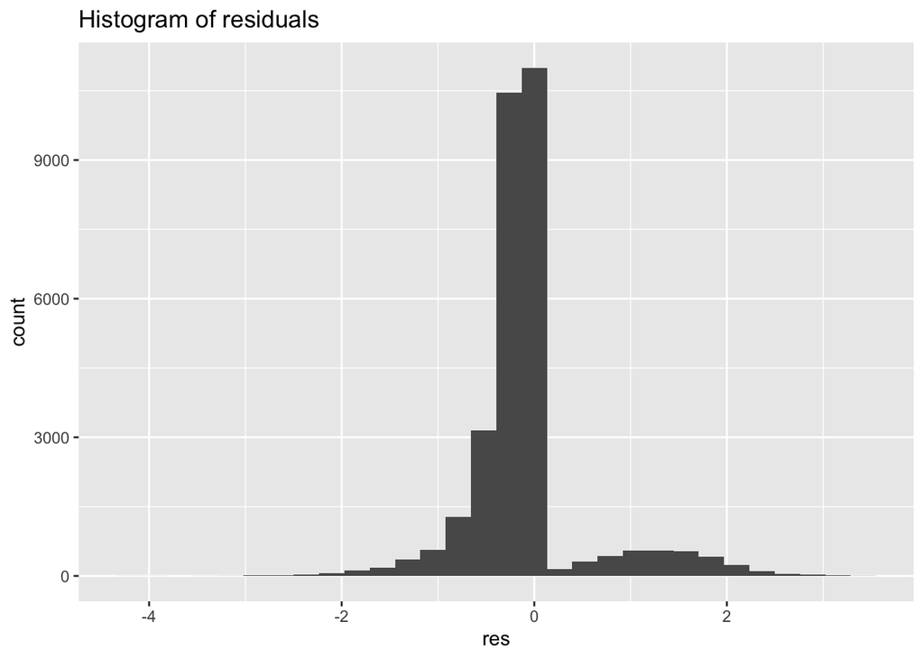

```r
bankTrain2 <- bankTrain %>%
  mutate(res = resid(reg6), fit = fitted(reg6))
bankTrain2 %>% ggplot(aes(res)) + geom_histogram() + labs(title = "Histogram of residuals")
```

The histogram of residual is unbalanced. This may be due to the unbalanced dataset that we have (more ‘no’ than ‘yes’ for `deposit`). However, the distribution still centers at 0 so this is still acceptable. We will also run the Hosmer-Lem test to check for binormiality.

```r
hoslem.test(bankTrain2$deposit, bankTrain2$fit,g=3000)
```

```
##
##  Hosmer and Lemeshow goodness of fit (GOF) test
##
## data:  bankTrain2$deposit, bankTrain2$fit
## X-squared = 2891.9, df = 2998, p-value = 0.9159
```

We change the number of bins to 3000 to fit the size of the dataset. The p-value is 0.9159. It is not statistically significant (higher than 0.05) so we fail to reject the null hypothesis that the residuals have a binormal distribution.

#### Prediction

We will start with predicting 3 random observations from the test set.

```r
bankTest2 <- bankTest %>%
  mutate(logDuration = log(duration)) %>%
  mutate(higherEd = ifelse(education == "professional.course" | education == "university.degree", 1 ,0)) %>%
  filter(logDuration != -Inf)

set.seed(4)
N <- seq(7649)
random <- sample(N, 3)
bankTestPt <- bankTest2[random, ]

bankTestPt <- bankTestPt %>%
  mutate(result = 0)
bankTestPt[1, 'result'] <- predict(reg6, bankTestPt[1,], type = "response")
bankTestPt[2, 'result'] <- predict(reg6, bankTestPt[2,], type = "response")
bankTestPt[3, 'result'] <- predict(reg6, bankTestPt[3,], type = "response")
bankTestPt %>%
  dplyr::select(deposit, result)
```

```
## # A tibble: 3 × 2
##   deposit result
##     <dbl>  <dbl>
## 1       1 0.271
## 2       0 0.0109
## 3       0 0.0621
```

The result when the actual deposit is 1 is quite higher than the results when the actual deposits are 0 but still not high enough. We will make some calculations (Recall, Precision, and Accuracy) to better assess the result.

```r
bankTest3 <- bankTest2 %>%
  mutate(predict = predict(reg6, bankTest2, type = "response")) %>%
  mutate(predictDeposit = ifelse(predict < 0.5,0,1))

N <- seq(nrow(bankTest3))

for (i in N) {
  if ((bankTest3[i,'predictDeposit'] == 0) && (bankTest3[i, 'deposit'] == 1)) {
    bankTest3[i,'result'] = "FN"
  }
  else if ((bankTest3[i,'predictDeposit'] == 1) && (bankTest3[i, 'deposit'] == 1)) {
    bankTest3[i,'result'] = "TP"
  }
  else if ((bankTest3[i,'predictDeposit'] == 1) && (bankTest3[i, 'deposit'] == 0)) {
    bankTest3[i,'result'] = "FP"
  }
  else {
    bankTest3[i,'result'] = "TN"
  }
}

FN <- sum(bankTest3$result == "FN")
FP <- sum(bankTest3$result == "FP")
TN <- sum(bankTest3$result == "TN")
TP <- sum(bankTest3$result == "TP")
recall <- TP/(TP + FN)
precision <- TP/(TP + FP)
accuracy <- (TP + TN)/(FP + FN + TP + TN)

recall
```

```
## [1] 0.4383562
```

```r
precision
```

```
## [1] 0.6748682
```

```r
accuracy
```

```
## [1] 0.9114685
```

- Recall: From all the customers subscribe to the term deposit, we predict 43.8% of them.
- Precision: From all the customers we predict that they subscribe, 67.4% of them actually do.
- Accuracy: Fromm all predictions, 91.14% is correct.